# Monitora RS: COVID-19 nos municípios do Rio Grande do Sul - 20ª Semana Epidemiológica

Juliana Sena de Souza$^1$, Márcia Helena Barbian$^2$, Rodrigo Citton Padilha dos Reis$^{2,3}$, Gabriel Holmer Saul$^4$, Gustavo Machado Utpott$^4$ e Franciele Lobo Pallaoro$^4$.

1. Mestranda em Epidemiologia, Universidade Federal do Rio Grande do Sul
2. Departamento de Estatística, Universidade Federal do Rio Grande do Sul
3. Programa de Pós-Graduação em Epidemiologia, Universidade Federal do Rio Grande do Sul
4. Graduando(a) em Estatística, Universidade Federal do Rio Grande do Sul

# Introdução:

# Conjunto de Dados:

## Casos Confirmados

O Rio Grande do Sul já possui um total de 3122 casos confirmados de COVID-19 em 208 municípios. A Figura abaixo apresenta a quantidade de casos em cada cidade.

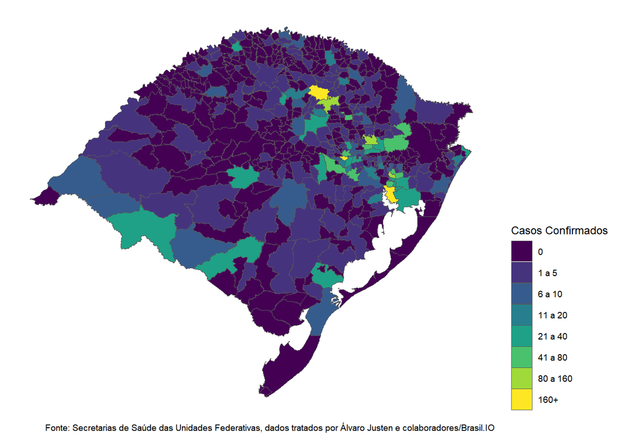

COVID-19: Casos Confirmados nos Municípios do RS - Acumulado por semana epidemiológica

Destaca-se que até o momento existem 3 municípios com uma quantidade de casos superior à 160. A Tabela presenta a lista de cidades que tiveram ao menos um caso confirmado:

| municipios | casos |
| --- | --- |
| Porto Alegre | 576 |
| Passo Fundo | 285 |
| Lajeado | 215 |
| Bento Gonçalves | 139 |
| Marau | 134 |
| São Leopoldo | 108 |
| Caxias do Sul | 72 |
| Taquari | 60 |
| Novo Hamburgo | 57 |
| Garibaldi | 56 |

[output cut: 198 more lines]

## Casos (por 100 mil hab.)

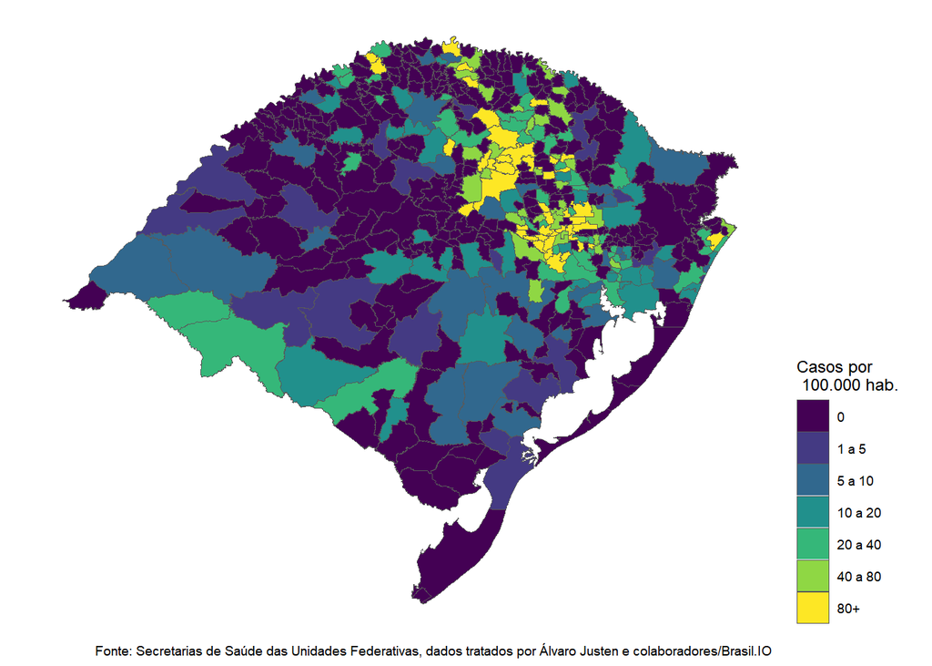

COVID-19: Casos (por 100 mil hab.) nos Municípios do RS - Acumulado por semana epidemiológica

## Óbitos

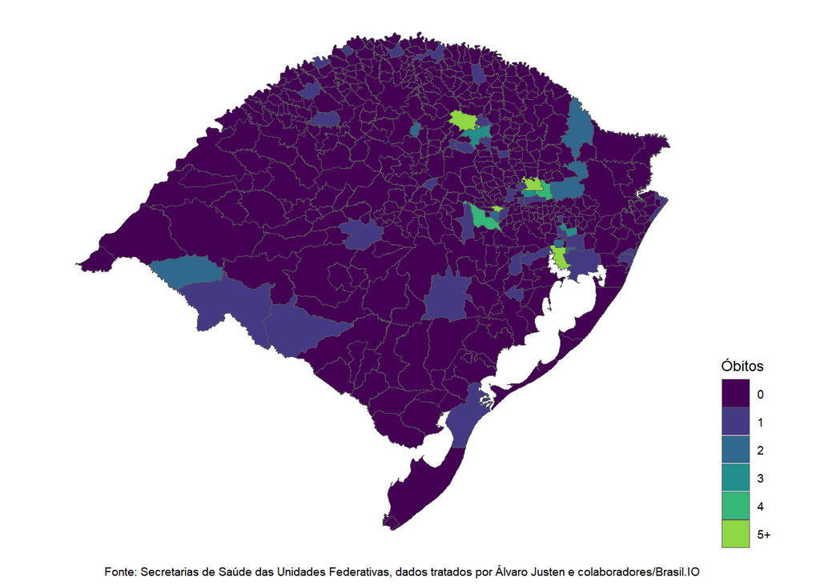

COVID-19: Óbitos Confirmados nos Municípios do RS - Acumulado por semana epidemiológica

## Letalidade

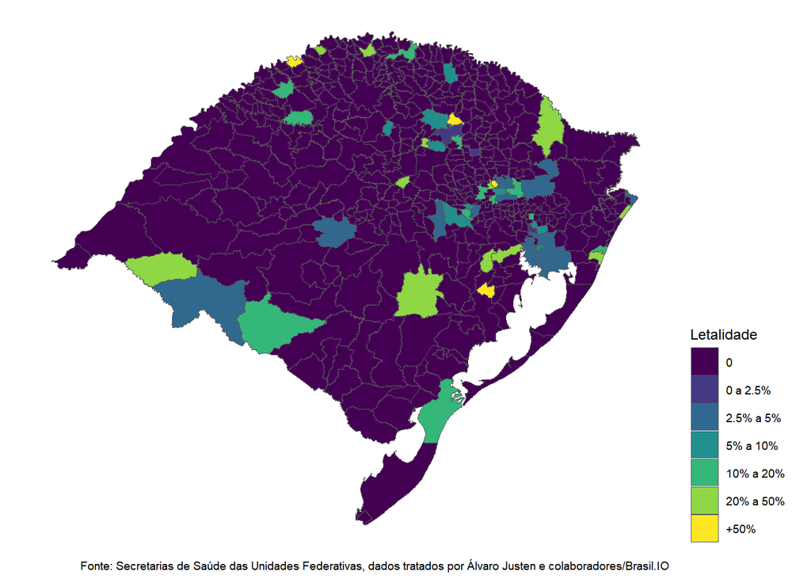

COVID-19: Letalidade nos Municípios do RS - Acumulado por semana epidemiológica

# Taxa de Incidência Padronizada:

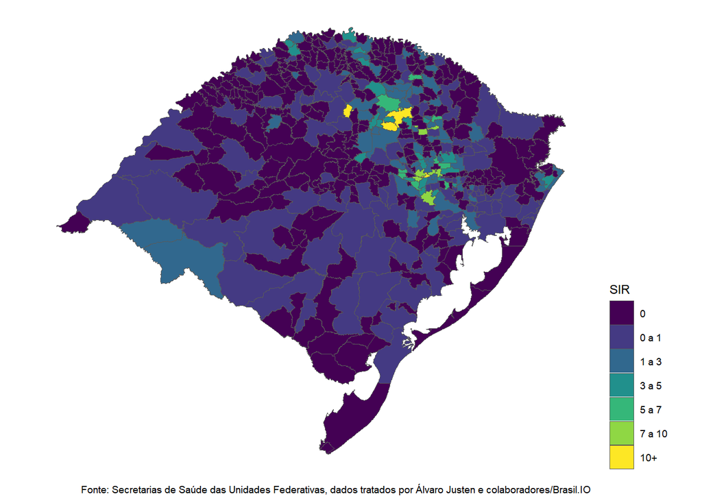

# Risco da doença (em áreas pequenas):

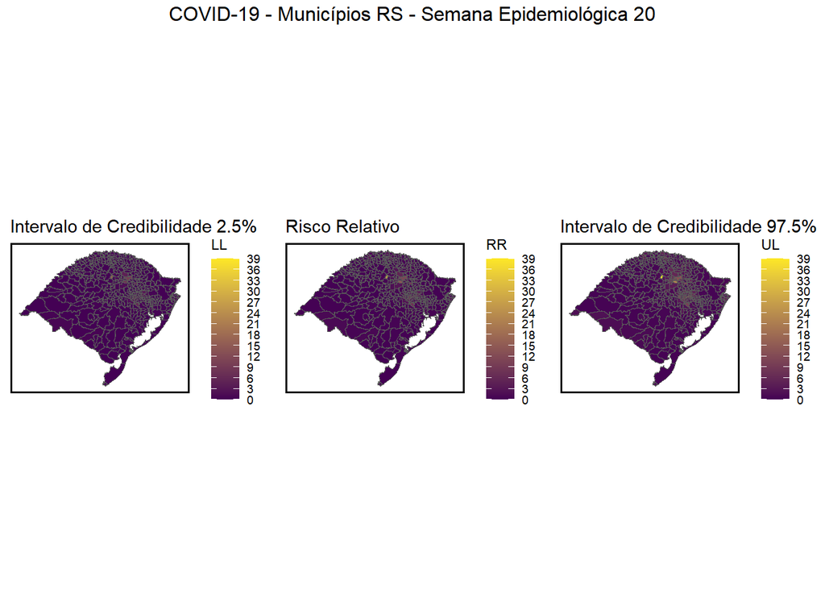

# Indicadores Locais de Associação Espacial:

## G

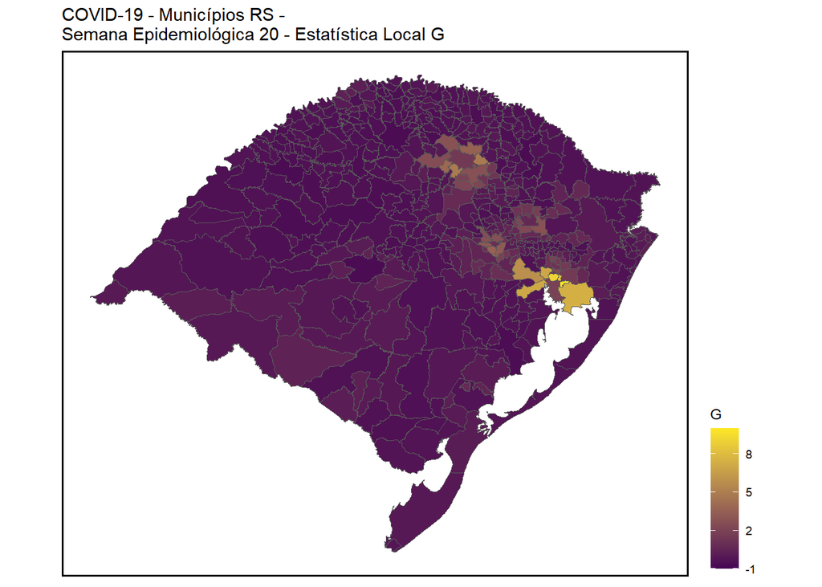

## G*

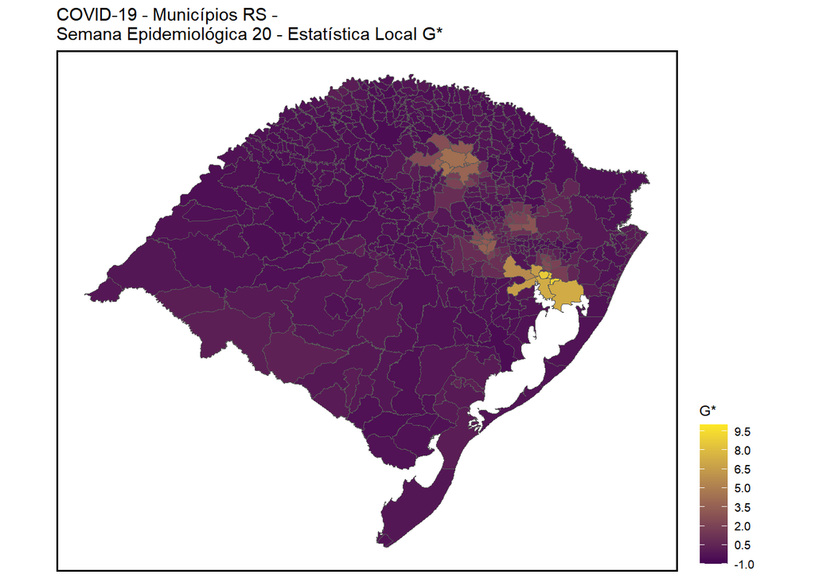

## I de Moran

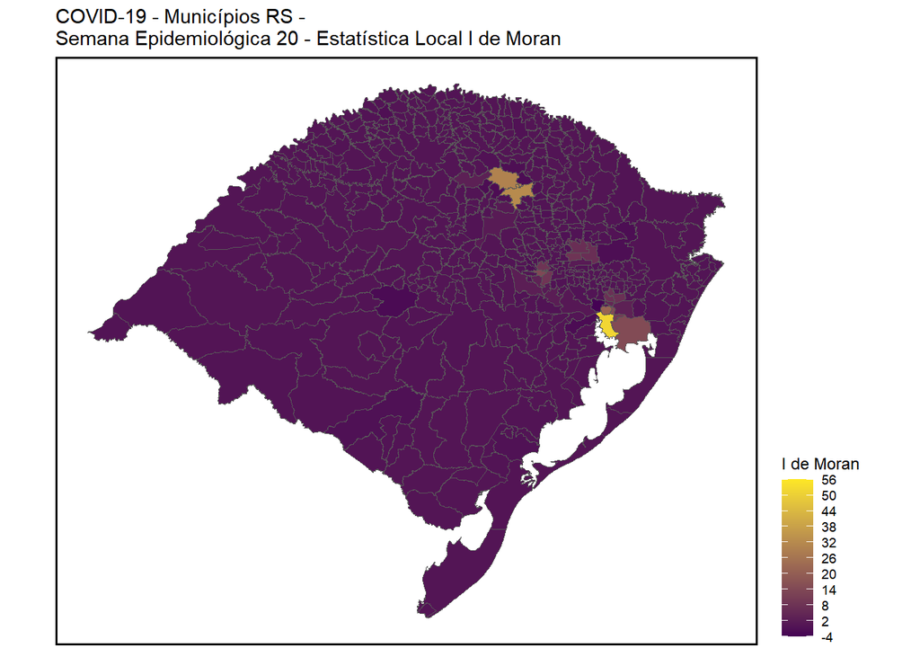

## LISA

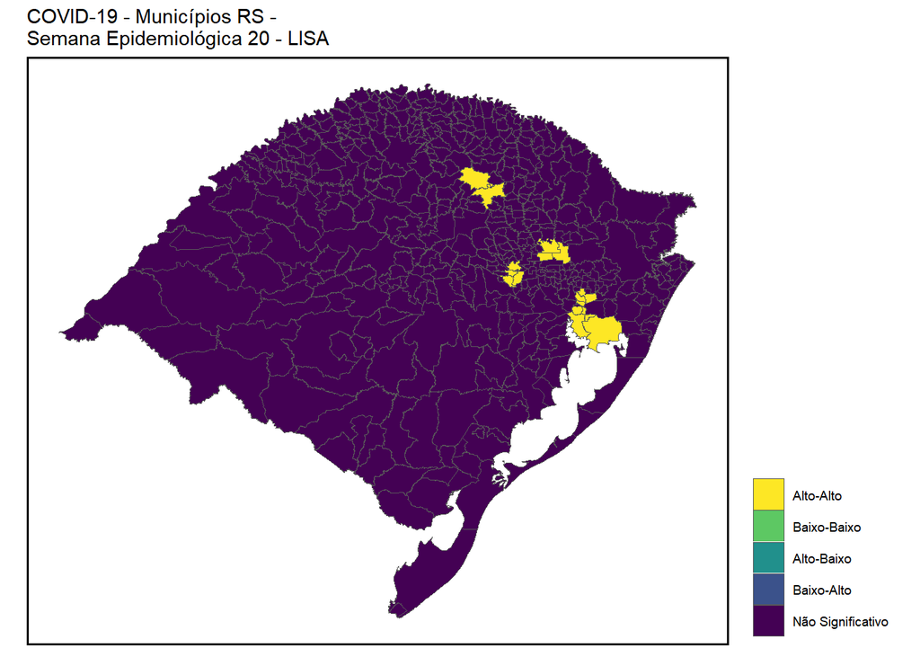

# Licença

This work is licensed under a [Creative Commons Attribution-ShareAlike 4.0 International License](http://creativecommons.org/licenses/by-sa/4.0/).

[figure not shown]

# Referências

Brasil.io. 2020. “Boletins Epidemiológicos Da Covid-19 Por Município Por Dia.” https://brasil.io/dataset/covid19/.